# SleepCycle Data Analysis Project

Tinashe M. Tapera

# Introduction

Sleep Cycle provides users with the ability to dump out and analyse the data they generate. I’m going to use this data to practice some of the data analysis methods I’ve learned and possibly understand more about my sleeping habits.

# The Dataset

Reading in the data:

```r
df = read.csv("sleepdata.csv", sep = ";", stringsAsFactors = FALSE)
df = as.data.frame(df)
head(df)
```

|  | Start | End | Sleep.quality | Time.in.bed | Wake.up | Sleep.Notes | Heart.rate | Activity..steps. |
| --- | --- | --- | --- | --- | --- | --- | --- | --- |
| 1 | 2011-04-08 17:50:51 | 2011-04-08 23:36:54 | 62% | 5:46 |  |  | NA | 0 |
| 2 | 2011-04-08 23:38:19 | 2011-04-09 01:46:04 | 24% | 2:07 |  |  | NA | 0 |
| 3 | 2011-04-09 16:18:02 | 2011-04-09 16:45:01 | 5% | 0:26 |  |  | NA | 0 |
| 4 | 2011-04-09 16:46:48 | 2011-04-09 23:50:06 | 66% | 7:03 |  |  | NA | 0 |
| 5 | 2011-04-10 08:29:42 | 2011-04-10 10:30:36 | 21% | 2:00 |  |  | NA | 0 |
| 6 | 2011-04-10 16:32:33 | 2011-04-11 01:48:22 | 94% | 9:15 |  |  | NA | 0 |

Let’s clean up each of the columns. There are a number of datetime columns, some factors, and a percentage column.

```r
df[,1:2] = lapply(df[,1:2], as.POSIXct)
df$Sleep.quality = as.numeric(sub("%","", df$Sleep.quality))
df$Wake.up = as.factor(df$Wake.up)
```

```r
#a function to turn the time in bed from
#the hh:mm format to total minutes
minuteParse = function(hhmm){
  temp = hhmm
  hours = as.numeric(strsplit(temp, split=":")[[1]][1])
  mins = as.numeric(strsplit(temp, split=":")[[1]][2])
  totalMins = (hours*60)+mins
  return(totalMins)
}
df$Time.in.bed = sapply(df$Time.in.bed, minuteParse)
```

```r
head(df)
```

|  | Start | End | Sleep.quality | Time.in.bed | Wake.up | Sleep.Notes | Heart.rate | Activity..steps. |
| --- | --- | --- | --- | --- | --- | --- | --- | --- |
| 1 | 2011-04-08 17:50:51 | 2011-04-08 23:36:54 | 62 | 346 |  |  | NA | 0 |
| 2 | 2011-04-08 23:38:19 | 2011-04-09 01:46:04 | 24 | 127 |  |  | NA | 0 |
| 3 | 2011-04-09 16:18:02 | 2011-04-09 16:45:01 | 5 | 26 |  |  | NA | 0 |
| 4 | 2011-04-09 16:46:48 | 2011-04-09 23:50:06 | 66 | 423 |  |  | NA | 0 |
| 5 | 2011-04-10 08:29:42 | 2011-04-10 10:30:36 | 21 | 120 |  |  | NA | 0 |
| 6 | 2011-04-10 16:32:33 | 2011-04-11 01:48:22 | 94 | 555 |  |  | NA | 0 |

Let’s take a look at some of the data that we have.

```r
summary(df)
```

```
     Start                          End
 Min.   :2011-04-08 17:50:51   Min.   :2011-04-08 23:36:54
 1st Qu.:2012-05-24 01:26:49   1st Qu.:2012-05-24 05:20:04
 Median :2013-12-19 15:47:53   Median :2013-12-19 22:58:29
 Mean   :2014-02-10 12:15:22   Mean   :2014-02-10 17:44:01
 3rd Qu.:2015-12-17 18:59:01   3rd Qu.:2015-12-18 01:27:25
 Max.   :2016-12-14 02:50:21   Max.   :2016-12-14 08:03:01

 Sleep.quality    Time.in.bed    Wake.up  Sleep.Notes
 Min.   : 0.00   Min.   :  0.0     :485   Length:1106
 1st Qu.:43.00   1st Qu.:258.0   :(: 58   Class :character
 Median :56.00   Median :334.0   :): 80   Mode  :character
 Mean   :55.36   Mean   :327.1   :|:483
 3rd Qu.:68.00   3rd Qu.:400.8
 Max.   :97.00   Max.   :766.0

   Heart.rate     Activity..steps.
 Min.   : 59.00   Min.   :    0
 1st Qu.: 70.00   1st Qu.:    0
 Median : 76.00   Median :    0
 Mean   : 76.53   Mean   : 2985
 3rd Qu.: 81.25   3rd Qu.: 6395
 Max.   :100.00   Max.   :24575
 NA's   :1046
```

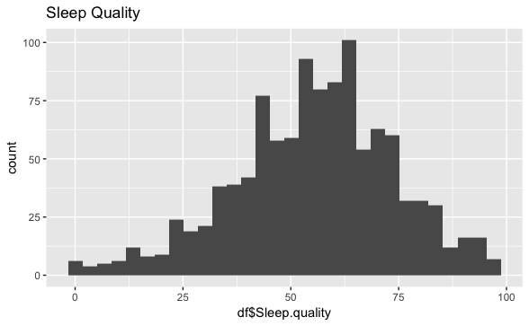

```r
ggplot(data=df)+
  geom_histogram(aes(x = df$Sleep.quality))+
  ggtitle("Sleep Quality")
```

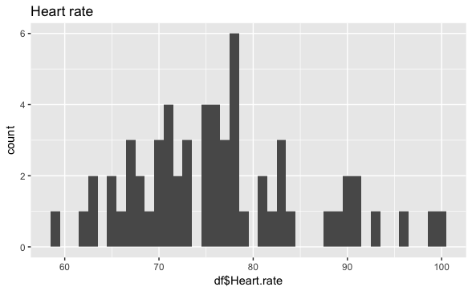

```r
ggplot(data=df)+
  geom_histogram(aes(x = df$Heart.rate), binwidth = 1)+
  ggtitle("Heart rate")
```

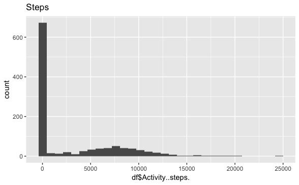

```r
ggplot(data=df)+
  geom_histogram(aes(x = df$Activity..steps.))+
  ggtitle("Steps")
```

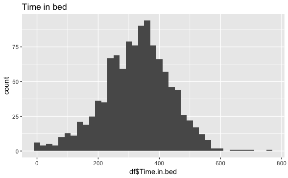

```r
ggplot(data=df)+
  geom_histogram(aes(x = df$Time.in.bed), binwidth=20)+
  ggtitle("Time in bed")
```

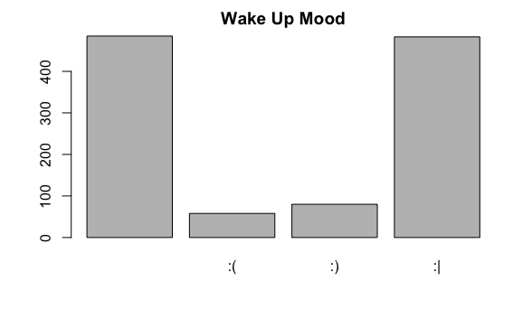

```r
plot(df$Wake.up, main = "Wake Up Mood")
```

There are a number of issues here. The first being that heart rate has over 1000 missing values. To be honest, I didn’t record heart rate very often, so it might be best to delete this variable. Additionally, it’s recorded *ex post facto*, meaning it’s not a predictive variable

```r
df$Heart.rate = NULL
```

The second issue is that the steps variable is also zero inflated; Sleep Cycle only implemented this once the iPhone developed a steps tracker; which in and of itself may be quite inaccurate (as a phone stays in your pocket, not your wrist).

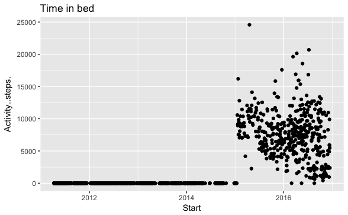

```r
ggplot(data=df)+
  geom_point(aes(y = Activity..steps., x = Start))+
  ggtitle("Time in bed")
```

One can’t possibly attempt to impute so many values; it would probably be best to throw this variable out and revisit it when I’ve racked up some more data with my fitbit (as I will with heartrate too).

```r
df$Activity..steps. = NULL
```

Lastly, there’s a class imbalance problem for the wake up mood. In my own opinion, it comes down to the fact that some days I’m actually too tired to even consider my own mood when I get up and have no time to think about it either. Let’s check the ratio of the data in mood:

```r
mood = table(df$Wake.up)
print(floor(mood/min(mood)))
```

```
   :( :) :|
 8  1  1  8
```

So the data imbalance is 1:1:8. It’s pretty difficult to work with classification problem when the data is so imbalanced in this way. It’s worth a try regardless, because there are methods developed for working with imbalanced data.

It’s first necessary to parse the Sleep notes column; I’d like to create dummy variables for each, as that seems the most appropriate method for classification problems.

```r
exampleString = df$Sleep.Notes[809]
exampleString
```

```
[1] "Long day:Lots of homework:Productive day:Satisfying day"
```

```r
#we can split a string and get each note in a list like so
strsplit(exampleString, ":")
```

```
[[1]]
[1] "Long day"         "Lots of homework" "Productive day"
[4] "Satisfying day"
```

```r
#so lets work through each night's note and enumerate the notes we have
getNotes = function(vec){
  allNotes = as.vector(unlist(strsplit(vec, ":")))
  return(unique(allNotes))
}
#create a df with each sleep note as a column
allNotes = getNotes(df$Sleep.Notes)
sleepNotes = data.frame(matrix(0,ncol = length(allNotes), nrow = dim(df)[1]))
names(sleepNotes) = allNotes
#now loop through the original data set and parse it as above,
#but this time, if the temp list contains a string that
#matches a column, mark that row in that column
makeNotes = function(dataframe,vec){

  for(i in 1:length(vec)){
    temp = as.vector(unlist(strsplit(vec[i], ":")))
    if(length(temp)>0){
      for(j in 1:length(temp)){
        hit = match(temp[j], names(dataframe))
        dataframe[i,hit] = 1
      }
    }
  }
  return(dataframe)
}
sleepNotes = data.frame(makeNotes(sleepNotes,df$Sleep.Notes))
apply(sleepNotes,2,table)
```

```
  Emotional.day Long.day Lots.of.homework Satisfying.day
0           999      885              933           1026
1           107      221              173             80
  Stressful.day Lazy.day Unproductive.day Went.out
0          1016     1055              976     1077
1            90       51              130       29
  Productive.day Stayed.in Watched.tv Fun.day Took.a.nap
0            988      1057        979    1091        949
1            118        49        127      15        157
  Exercised
0      1081
1        25
```

```r
df$Sleep.Notes = NULL
df = bind_cols(df,sleepNotes)
head(df)
```

|  | Start | End | Sleep.quality | Time.in.bed | Wake.up | Emotional.day | Long.day | Lots.of.homework | Satisfying.day | Stressful.day | Lazy.day | Unproductive.day | Went.out | Productive.day | Stayed.in | Watched.tv | Fun.day | Took.a.nap | Exercised |
| --- | --- | --- | --- | --- | --- | --- | --- | --- | --- | --- | --- | --- | --- | --- | --- | --- | --- | --- | --- |
| 1 | 2011-04-08 17:50:51 | 2011-04-08 23:36:54 | 62 | 346 |  | 0 | 0 | 0 | 0 | 0 | 0 | 0 | 0 | 0 | 0 | 0 | 0 | 0 | 0 |
| 2 | 2011-04-08 23:38:19 | 2011-04-09 01:46:04 | 24 | 127 |  | 0 | 0 | 0 | 0 | 0 | 0 | 0 | 0 | 0 | 0 | 0 | 0 | 0 | 0 |
| 3 | 2011-04-09 16:18:02 | 2011-04-09 16:45:01 | 5 | 26 |  | 0 | 0 | 0 | 0 | 0 | 0 | 0 | 0 | 0 | 0 | 0 | 0 | 0 | 0 |
| 4 | 2011-04-09 16:46:48 | 2011-04-09 23:50:06 | 66 | 423 |  | 0 | 0 | 0 | 0 | 0 | 0 | 0 | 0 | 0 | 0 | 0 | 0 | 0 | 0 |
| 5 | 2011-04-10 08:29:42 | 2011-04-10 10:30:36 | 21 | 120 |  | 0 | 0 | 0 | 0 | 0 | 0 | 0 | 0 | 0 | 0 | 0 | 0 | 0 | 0 |
| 6 | 2011-04-10 16:32:33 | 2011-04-11 01:48:22 | 94 | 555 |  | 0 | 0 | 0 | 0 | 0 | 0 | 0 | 0 | 0 | 0 | 0 | 0 | 0 | 0 |

# Setting Up the Problem

I want to better understand my sleeping habits, and I think the best way to do this would be through understanding the variables that influence the wake up mood. So my initial thought was that I could try and predict wake up mood using multinomial logistic regression, however, this might be difficult due to the class imbalance problem.

Nevertheless, I’ll attempt to fit a simple model and see how it performs.

# Examining the Variables

First, visualising the data to use:

```r
#refactor wakeup mood
df$Mood = as.numeric(df$Wake.up)
df$Mood[which(df$Wake.up == "")] = NA
df$Mood[which(df$Wake.up == ":|")] = 0
df$Mood[which(df$Wake.up == ":(")] = -1
df$Mood[which(df$Wake.up == ":)")] = 1
```

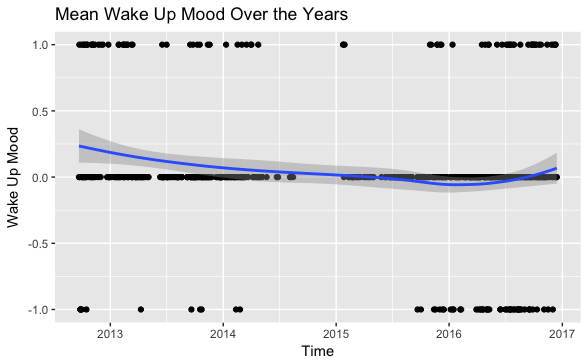

```r
df2 = df[which(is.na(df$Mood) == FALSE),]
ggplot(df2, aes(x = Start, y = Mood)) + geom_point() + xlab("Time") + scale_x_datetime() + ylab("Wake Up Mood")+
  geom_smooth()+ggtitle("Mean Wake Up Mood Over the Years")
```

```r
df$Mood = NULL
```

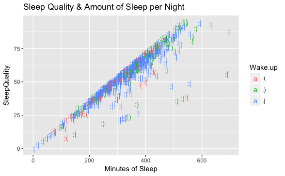

```r
ggplot(df2) + geom_text(aes(x = Time.in.bed, y = Sleep.quality, label = Wake.up, colour = Wake.up)) + xlab("Minutes of Sleep") + ylab("SleepQuality") + ggtitle("Sleep Quality & Amount of Sleep per Night")
```

```r
cor(df$Sleep.quality, df$Time.in.bed)
```

```
[1] 0.9401885
```

So it looks like minutes of sleep and sleep quality are strongly positively correlated (of course). This might be a problem in violating the assumptions of linear modeling.

```r
df = df[!(df$Wake.up == ""),]
df$Wake.up = factor(df$Wake.up)
summary(df[,1:5])
```

```
     Start                          End
 Min.   :2012-09-21 17:32:30   Min.   :2012-09-21 23:37:10
 1st Qu.:2013-10-15 04:13:49   1st Qu.:2013-10-15 07:28:33
 Median :2015-08-11 01:12:33   Median :2015-08-11 06:45:57
 Mean   :2015-02-11 13:34:10   Mean   :2015-02-11 19:05:38
 3rd Qu.:2016-05-09 04:17:39   3rd Qu.:2016-05-09 08:29:17
 Max.   :2016-12-14 02:50:21   Max.   :2016-12-14 08:03:01
 Sleep.quality    Time.in.bed    Wake.up
 Min.   : 0.00   Min.   :  0.0   :(: 58
 1st Qu.:43.00   1st Qu.:260.0   :): 80
 Median :55.00   Median :337.0   :|:483
 Mean   :54.77   Mean   :330.6
 3rd Qu.:67.00   3rd Qu.:402.0
 Max.   :95.00   Max.   :696.0
```

We can see the distributions of the continuous data below:

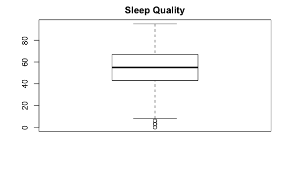

```r
boxplot(df$Sleep.quality, main = "Sleep Quality")
```

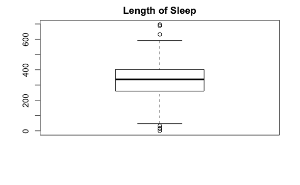

```r
boxplot(df$Time.in.bed, main = "Length of Sleep")
```

Notice that there are outliers for each of these variables. However, I don’t want to lose too much data by deleting them. In fact, they are probably the points that we want the model to be sensitive to (after all, if every time I get 1 hour of sleep is the times that I have a bad mood, then the model should be sensitive to that). That being said, I’ll only remove the rows where I got less than an hour of sleep (because that would technically be a nap and wouldn’t require SleepCycle).

```r
df = df[!(df$Time.in.bed < 60),]
nights = df[,1:2]
df[,1:2] = NULL
rownames(df) = nights$Start
```

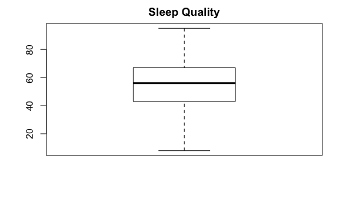

```r
boxplot(df$Sleep.quality, main = "Sleep Quality")
```

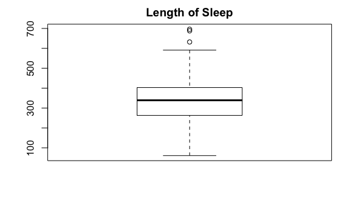

```r
boxplot(df$Time.in.bed, main = "Length of Sleep")
```

Nice.

We can more closely examine the predictors in sleep notes:

```r
vars = NULL
for(i in 4:17){
  print(names(df)[i])
  temp = df[,i]
  ratio = as.vector(table(temp))
  ratio = ((ratio[2]/ratio[1])*100)%>%
    round(.,2)
  paste(ratio,"%")%>%
    print()
  vars = rbind(vars,ratio)
}
```

```
[1] "Emotional.day"
[1] "18.08 %"
[1] "Long.day"
[1] "46.19 %"
[1] "Lots.of.homework"
[1] "33.77 %"
[1] "Satisfying.day"
[1] "13.28 %"
[1] "Stressful.day"
[1] "14.77 %"
[1] "Lazy.day"
[1] "8.67 %"
[1] "Unproductive.day"
[1] "23.79 %"
[1] "Went.out"
[1] "4.24 %"
[1] "Productive.day"
[1] "20.39 %"
[1] "Stayed.in"
[1] "7.72 %"
[1] "Watched.tv"
[1] "23.79 %"
[1] "Fun.day"
[1] "1.82 %"
[1] "Took.a.nap"
[1] "30.64 %"
[1] "Exercised"
[1] "3.54 %"
```

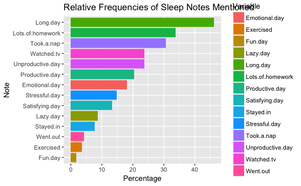

```r
vars = as.data.frame(vars)
rownames(vars) = NULL
vars$Variable = names(df)[4:17]
vars = vars[order(-vars$V1),]
ggplot(vars)+
  geom_bar(aes(x = with(vars, reorder(Variable,V1)), y = V1, fill = Variable), stat = "identity")+
  ylab("Percentage")+
  xlab("Note")+
  coord_flip()+
  ggtitle("Relative Frequencies of Sleep Notes Mentioned")
```

Simple visualisations show that over 40% of my days are regarded as long days (my equivalent to saying I wish I had had less to do).

About 2% of the time, I indicate that it was a fun day. Not super encouraging.

Something else that’s worrying is that I mention unproductive days more frequently than productive days. Furthermore, I only exercised about 3% of these days too!

And of course, taking a nap, lots of homework, and a little bit of TV before bed are always going to be present.

You can clearly see where my priorities are at.

But will a regression result mimic these observations?

# Fitting a Multinomial Logistic Regression Model

We’ll fit a multinomial logistic regression model using the `nnet` package. The data set has dimensions 614, 17, and spans nights from 2012-09-21 17:32:30 to 2016-12-14 08:03:01.

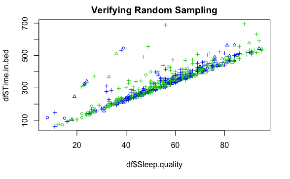

```r
# we need to truly randomise the subset that we use for modeling.
# because we are really violating the assumption of uncorrelated
# observations since it is a linear dataset
set.seed(1)
ind = sample(1:dim(df)[1],0.6*dim(df)[1])
binaryTrain = ifelse(1:dim(df)[1] %in% ind, 1,2)
plot(df$Sleep.quality, df$Time.in.bed, col = binaryTrain+10, cex = 0.7, pch = as.numeric(df$Wake.up), main = "Verifying Random Sampling")
```

```r
train = df[ind,]
model1 = multinom(Wake.up~., train)
summary(model1)
```

```
Call:
multinom(formula = Wake.up ~ ., data = train)

Coefficients:
   (Intercept) Sleep.quality Time.in.bed Emotional.day
:)  -2.0351907    0.02934627 0.004723354    -1.2019508
:|   0.6567463    0.03308257 0.002052723    -0.5274769
     Long.day Lots.of.homework Satisfying.day Stressful.day
:) -0.3094883       -0.2819415      0.1999768    -0.1829924
:|  0.4602935       -0.1691941      0.7273376    -1.2294273
     Lazy.day Unproductive.day Went.out Productive.day
:) -1.1491519       -1.5497615 1.575614      -2.128149
:| -0.2593855       -0.7029491 1.230660      -1.107775
    Stayed.in Watched.tv    Fun.day Took.a.nap  Exercised
:)  0.6763165  0.2155899 -15.884250  0.4188251  0.5206860
:| -0.7265632 -0.6414547  -1.134042 -0.2485300 -0.1862393

Std. Errors:
   (Intercept) Sleep.quality Time.in.bed Emotional.day
:)   0.8957162    0.03542193 0.005793121     0.8059876
:|   0.6580904    0.03032648 0.004994926     0.4816959
    Long.day Lots.of.homework Satisfying.day Stressful.day
:) 0.7714650         0.828245      1.0139333     0.7770740
:| 0.5330554         0.543653      0.7355973     0.4999211
    Lazy.day Unproductive.day Went.out Productive.day
:) 1.0680311        0.8168032 1.728603      0.9214362
:| 0.6432792        0.5789945 1.247001      0.6372228
   Stayed.in Watched.tv      Fun.day Took.a.nap Exercised
:) 0.9573785  0.7550245 3.419365e-06  0.8430131 1.0421259
:| 0.6424556  0.4924671 1.024357e+00  0.5647034 0.7299486

Residual Deviance: 414.7438
AIC: 482.7438
```

## Interpretation

In other words, taking the exponent of the coefficients, **the [relative odds](http://data.princeton.edu/wws509/stata/mlogit.html) of waking up in a better mood for each of the conditions are summarised by the following table:**

```r
coef(model1)%>%
  exp()%>%
  kable(., digits = 3, caption = "Relative Odds of Waking Up in a Better Mood")
```

|  | (Intercept) | Sleep.quality | Time.in.bed | Emotional.day | Long.day | Lots.of.homework | Satisfying.day | Stressful.day | Lazy.day | Unproductive.day | Went.out | Productive.day | Stayed.in | Watched.tv | Fun.day | Took.a.nap | Exercised |
| --- | --- | --- | --- | --- | --- | --- | --- | --- | --- | --- | --- | --- | --- | --- | --- | --- | --- |
| :) | 0.131 | 1.030 | 1.005 | 0.301 | 0.734 | 0.754 | 1.221 | 0.833 | 0.317 | 0.212 | 4.834 | 0.119 | 1.967 | 1.241 | 0.000 | 1.52 | 1.683 |
| :\| | 1.929 | 1.034 | 1.002 | 0.590 | 1.585 | 0.844 | 2.070 | 0.292 | 0.772 | 0.495 | 3.423 | 0.330 | 0.484 | 0.527 | 0.322 | 0.78 | 0.830 |

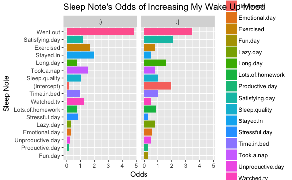

```r
odds = coef(model1)%>%
  exp()%>%
  as.data.frame()%>%
  t()
odds = as.data.frame(odds)
odds$Variable = as.vector(rownames(odds))
odds = gather(odds,Mood,Odds, 1:2)
ggplot(odds)+
  geom_bar(aes(x = with(odds, reorder(Variable,Odds)), y = Odds, fill = Variable), stat = "identity")+
  coord_flip()+
  facet_wrap(~Mood)+
  xlab("Sleep Note")+
  ggtitle("Sleep Note's Odds of Increasing My Wake Up Mood")
```

We can also interpret the model coefficients using the Wald’s *z*-test to find their significance at the 0.95 $\alpha$-level:

```r
# acknowledge:
# http://stats.stackexchange.com/questions/63222/getting-p-values-for-multinom-in-r-nnet-package
z = summary(model1)$coefficients/summary(model1)$standard.errors
p = ((1 - pnorm(abs(z), 0, 1)) * 2) %>%
  as.data.frame()
p
```

|  | (Intercept) | Sleep.quality | Time.in.bed | Emotional.day | Long.day | Lots.of.homework | Satisfying.day | Stressful.day | Lazy.day | Unproductive.day | Went.out | Productive.day | Stayed.in | Watched.tv | Fun.day | Took.a.nap | Exercised |
| --- | --- | --- | --- | --- | --- | --- | --- | --- | --- | --- | --- | --- | --- | --- | --- | --- | --- |
| :) | 0.02307819 | 0.4074002 | 0.4148786 | 0.1358888 | 0.6882953 | 0.7335491 | 0.8436485 | 0.81382919 | 0.2819480 | 0.05778175 | 0.3620343 | 0.02091030 | 0.4799236 | 0.7752302 | 0.0000000 | 0.6193166 | 0.6173298 |
| :\| | 0.31829993 | 0.2753254 | 0.6811006 | 0.2734986 | 0.3878625 | 0.7556356 | 0.3227750 | 0.01392305 | 0.6867836 | 0.22471491 | 0.3236934 | 0.08213298 | 0.2580905 | 0.1927342 | 0.2682606 | 0.6598595 | 0.7986147 |

```r
for(i in 1:length(p)){
  temp = p[,i]
  if(temp[2] < 0.05){
    print(paste(names(p)[i],"is significant for :| mood:",round(temp[2],4)))
  }
  if(temp[1] < 0.05){
    print(paste(names(p)[i],"is significant for :) mood:",round(temp[1],4)))
  }
}
```

```
[1] "(Intercept) is significant for :) mood: 0.0231"
[1] "Stressful.day is significant for :| mood: 0.0139"
[1] "Productive.day is significant for :) mood: 0.0209"
[1] "Fun.day is significant for :) mood: 0"
```

The only predictors that were significant for my wake up mood in this model were stressful days (reduced probability), fun days (reduced probability), and whether or not the day was productive (reduced probability). I’m quite surprised by the directions of the coefficients in each case.

## Making Predictions

We can evaluate the model fit by predicting on the portion of the data that we left out.

```r
test = df[-ind,]
yhat = predict(model1, newdata = test, type = "class")
y = df[-ind,"Wake.up"]
```

```r
table(yhat,y)
```

```
    y
yhat  :(  :)  :|
  :(   2   1   3
  :)   0   1   0
  :|  17  40 182
```

# Improving The Model By Adding Sampling Weights

To remedy the data imbalance problem, a common method is to add weights to a model.

According to [King (2001)](https://academic.oup.com/pan/article-abstract/9/2/137/1548158/Logistic-Regression-in-Rare-Events-Data?rss=1&ssource=mfc):

> In rare events (such as fraud in credit risk, deaths in medical literature) we tend to sample all the 1’s (rare events) and a fraction of 0’s (non events). In such cases we have to weight the observations accordingly. Example: Let us say, In a population of 500,000 transactions there are 50 fraud transactions. In this case you would sample all 50 frauds transaction (100% of the fraud) & 10% of the good transactions (10% of 500,000 is 5000 good transactions). In this case you would assign a weight of 1 for fraud transactions and a weight of 10 for good transactions. This is called the Weighted Maximum Likelihood method. The important takeaway is that the weighting is related to sampling proportions

In this case, then we should sample ALL of the minority classes in the training set, weight them as 1, and sample 10% of the majority class, weighting it as 10.

```r
n = 10
train = df[ind,]
# 100% of minority groups in training set
minor = which(train$Wake.up != ":|")
minor_weight = rep(1,length(minor))
# n% of the majority class
major = which(train$Wake.up == ":|")
set.seed(1)
major = sample(major,length(major)/n)
major_weight = rep(n,length(major))
wt = c(minor_weight,major_weight)
train = df[c(minor,major),]
```

Now we fit the model as normal, incorporating the weights vector.

```r
model2 = multinom(Wake.up~., train, weights = wt)
summary(model2)
```

```
NaNs produced
```

```
Call:
multinom(formula = Wake.up ~ ., data = train, weights = wt)

Coefficients:
   (Intercept) Sleep.quality Time.in.bed Emotional.day
:)   0.4287509    0.17918464 -0.02493498      -11.2360
:|   2.7346980    0.07407829 -0.01004066      128.8867
     Long.day Lots.of.homework Satisfying.day Stressful.day
:) -105.33360         42.37690      -19.07229      -9.41724
:|  -10.49511        -70.64689      -37.96098      49.83032
   Lazy.day Unproductive.day Went.out Productive.day
:)        0        -103.0739        0       41.69142
:|        0          57.1187        0       95.64980
   Stayed.in Watched.tv Fun.day Took.a.nap Exercised
:)         0          0       0          0         0
:|         0          0       0          0         0

Std. Errors:
   (Intercept) Sleep.quality Time.in.bed Emotional.day
:)   1.0890780    0.06147676 0.008321836           NaN
:|   0.9925024    0.05169884 0.006369434  4.348481e-07
       Long.day Lots.of.homework Satisfying.day Stressful.day
:)          NaN     2.277169e-16   1.295250e-16  9.608875e-40
:| 4.969966e-07     4.969966e-07   4.396636e-07  9.608875e-40
   Lazy.day Unproductive.day Went.out Productive.day
:)        0     1.534372e-64        0   1.676895e-16
:|        0     2.576198e-10        0   6.239552e-08
   Stayed.in Watched.tv Fun.day Took.a.nap Exercised
:)         0          0       0          0         0
:|         0          0       0          0         0

Residual Deviance: 385.0152
AIC: 425.0152
```

And predict:

```r
test = df[-ind,]
yhat = predict(model2, newdata = test, type = "class")
y = df[-ind,"Wake.up"]
table(yhat,y)
```

```
    y
yhat  :(  :)  :|
  :(   4   4  14
  :)   2   3   3
  :|  13  35 168
```

```r
round(mean(yhat == y)*100)
```

```
[1] 71
```

This didn’t improve the model; We can see that in the confusion matrix, the model didn’t overfit as badly and varied more. But it still didn’t improve its accuracy, so either the weights are badly selected, or, this is a particularly complex problem to tackle.

# Summary

# Future Improvements

The first problem is quite obvious; this modeling technique ignores the basic principle that observations shouldn’t be correlated for logistic regression. A more appropriate model would be one that incorporates longitudinal data analysis methods such as growth curve modeling.

A second issue is that two variables we used were extremely collinear. Whether this violation caused the downfall of the model is up to question.

According to [Machine Learning Mastery](http://machinelearningmastery.com/tactics-to-combat-imbalanced-classes-in-your-machine-learning-dataset/), one approach to this problem is to change approaches completely. In this case, it might be wise to investigate [change detection](https://en.wikipedia.org/wiki/Change_detection), a statistical learning problem where the goal is to identify when the probability distribution of a time series is going to change significantly.

This might be appropriate for this data set because Sleep Cycle has provided all the dates for each measurement; also, it is fitting because on most mornings my mood is within a very wide range that I consider :|, and in order for me to put in a :) or :(, something pretty significant must have happened to my mood. Detecting and predicting this change would be a useful insight for myself as I could better modulate my mood and perhaps even respond to it early by sending myself a pick me up early in the morning.